# DCGR 02 - Crime Preference in Champaign County

Andrew Vanthournout, Michael Zhuang, Xingnuo Duan

Due 12/21/2019

## Abstract

We conduct a multivariate analysis of CCSO Bookings dataset, which contains individuals who were booked into jail in Champaign County between the years 2011-2016. The main method of this report includes decision tree, text mining, and clustering analysis, supported with statistic tables and visualizations. We focus on examining the pattern of crime committed by different group of people in Champaign County. Specifically, we make analysis separately for students, employed or unemployed, and military.

## Introduction

For residents in Champaign, one of the most important thing they should care about is the safety of their living environment. Unfortunately, Champaign is not one of the safest communities in America. Actually, according to the FBI crime data, crime rate of Champaign is higher than 93% of the state’s cities and towns of all sizes. Also, it is much higher than the state average and the national average, as Annual Crime Data suggests. It means that for every 100 thousand people, there are about 10 daily crimes. Therefore, people may be curious how crime code diverse in different groups of people, and some implicit patterns of crime behind the data are worth of study. A thorough statistical analysis could help local government and police officers have better idea in preventing potential crime happen in the future, and also help the residents in Champaign to foresee and keep away from dangerous.

The CCSO Booking dataset we used contains over 67764 observations and 12 columns for individuals who were booked into jail in Champaign County between the years 2011-2016. The individuals are not identifiable based on personal identity, but they are given unique jacket numbers. The demographics of the people, reasons for being booked, and crime code are also given in the data. The original source is the Champaign County Sheriff Office (CCSO), which can be found in https://github.com/CUHackNight/JailData.

In this report we investigate the “preference of crime”, or patterns in committing crime, for different groups of people in Champaign County. First we look at empoyment status, specifically empolyed vs unemployed. We will look into which types of crimes are being committed most often by each employment group and attempt to draw some conculsions about these results. We will then do some text mining on the crime codes of these people to help visualize these results. Next, for the student group, we specificlly pay attention to their age (Age at Arrest) and the types of crime (Crime Code) committed by students, which we explore the diversion of crime type based on different age. We build a decision tree model for the two most frequent types of crime that are committed by students, and look for some interesting patterns associate with their age. Lastly, we looked at the people with military backgrounds. We first used k-means clustering to separate these people into three clusters based on their demographics, and then we examined the common pattern and unique patterns in each of these clusters.

## Analysis

#### Employed or Unemployed Group - Crime Code Diversion in Occupation

First We will look at some basic statistics for employment status and crime codes to help us get a better understanding of the data set.

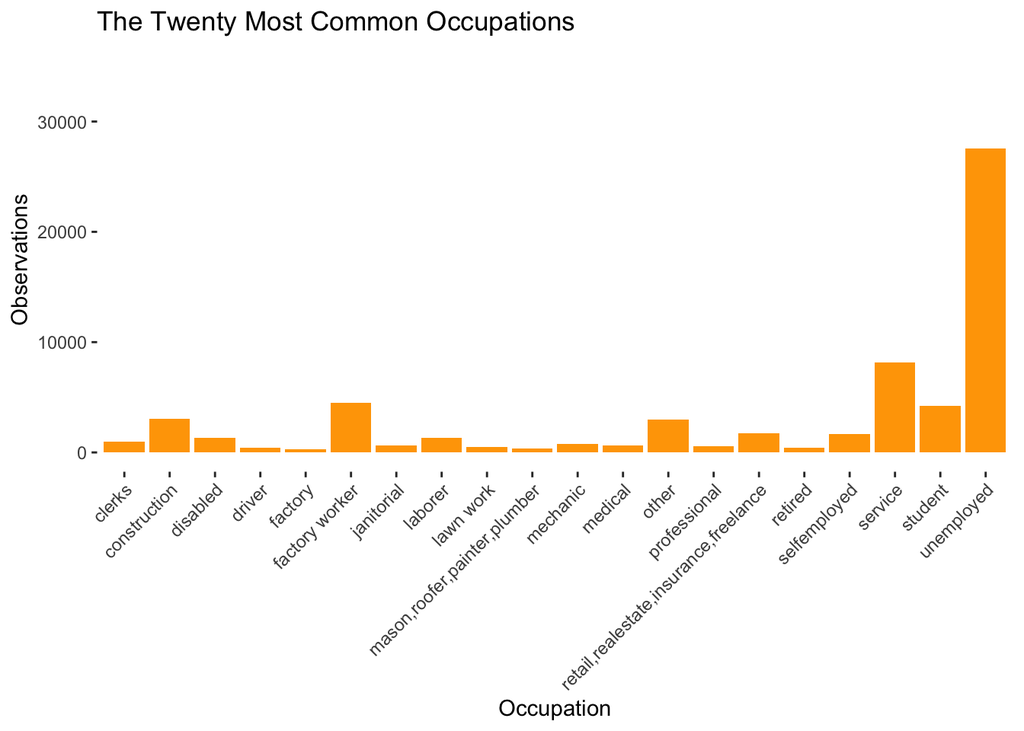

```r
ggplot(data = Occ_namesFixed,aes(x=Occupation,y=common_occ$n))+
  geom_bar(stat = "identity", fill = "orange")+
  theme(axis.text.x=element_text(angle=45,hjust=1,vjust=1),panel.grid.major = element_blank(), panel.grid.minor = element_blank(),
panel.background = element_blank())+
  xlab("Occupation")+
  ylab("Observations")+
  ylim(c(0,35000))+
  ggtitle("The Twenty Most Common Occupations")
```

This graph shows us the twenty most common occupations that appear in our dataset. It is easy to see that the category “unemployed” has by far the most occurances. The occupations: service, student, factory worker, and construction are aslo noticably above the others.

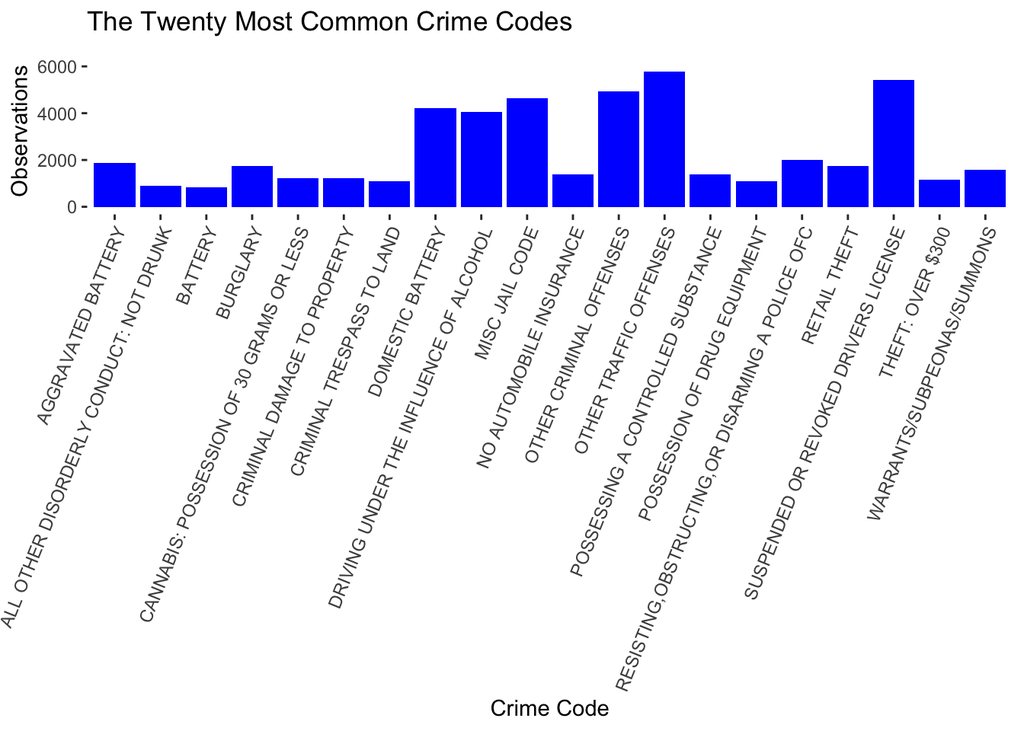

```r
ggplot(data = common_cc,aes(x=CC,y=common_cc$n))+
  geom_bar(stat = "identity", fill = "blue")+
  theme(axis.text.x=element_text(angle=68,hjust=1,vjust=1),panel.grid.major = element_blank(), panel.grid.minor = element_blank(),
panel.background = element_blank())+
  xlab("Crime Code")+
  ylab("Observations")+
  ylim(c(0,6500))+
  ggtitle("The Twenty Most Common Crime Codes")
```

This grapgh shows us the twenty most common crime codes that appear in our data set. Domestic Battery, DUI, and Suspended or Revoked Drivers Licensce are the most common occurances other than broad categories such as “misc. jail code” or “other criminal offenses”.

Now we will seperate our data set into employed and unemployed, and categorized our crimes into five categories: violent/malicious, traffic violations, drug violations, justice system related crimes, and other.

```r
unemployed <- CCSO[CCSO$occupation == "UNEMPLOYED",]
count_cc <- na.omit(count(unemployed,`crime code`))
count_cc_top <- count_cc[count_cc$n>417,]
```

Violent or Malicious crimes for unemployed people:

```r
violent_malicious <- count_cc_top[count_cc_top$`crime code` == "AGGRAVATED BATTERY"|count_cc_top$`crime code` == "BURGLARY"|count_cc_top$`crime code` =="DOMESTIC BATTERY"|count_cc_top$`crime code` == "CRIMINAL DAMAGE TO PROPERTY"|count_cc_top$`crime code` ==   "THEFT: OVER $300"|count_cc_top$`crime code` == "CRIMINAL TRESPASS TO LAND"|count_cc_top$`crime code` =="RETAIL THEFT",]
violent_malicious
```

```
## # A tibble: 7 x 2
##   `crime code`                    n
##   <chr>                       <int>
## 1 AGGRAVATED BATTERY            864
## 2 BURGLARY                     1042
## 3 CRIMINAL DAMAGE TO PROPERTY   594
## 4 CRIMINAL TRESPASS TO LAND     644
## 5 DOMESTIC BATTERY             1673
## 6 RETAIL THEFT                  968
## 7 THEFT: OVER $300              635
```

```r
violent_malicious_sum = sum(violent_malicious$n)
```

Traffic violations for unemployed people:

```r
traffic <- count_cc_top[count_cc_top$`crime code` =="OTHER TRAFFIC OFFENSES"|count_cc_top$`crime code` == "SUSPENDED OR REVOKED DRIVERS LICENSE",]
traffic
```

```
## # A tibble: 2 x 2
##   `crime code`                             n
##   <chr>                                <int>
## 1 OTHER TRAFFIC OFFENSES                1268
## 2 SUSPENDED OR REVOKED DRIVERS LICENSE  1984
```

```r
traffic_sum = sum(traffic$n)
```

Drug violations for unemployed people:

```r
drugs <- count_cc_top[count_cc_top$`crime code` == "POSSESSION OF DRUG EQUIPMENT"|count_cc_top$`crime code` == "CANNABIS: POSSESSION OF 30 GRAMS OR LESS"|count_cc_top$`crime code` == "POSSESSING A CONTROLLED SUBSTANCE"|count_cc_top$`crime code` == "DRIVING UNDER THE INFLUENCE OF ALCOHOL",]
drugs
```

```
## # A tibble: 4 x 2
##   `crime code`                                 n
##   <chr>                                    <int>
## 1 CANNABIS: POSSESSION OF 30 GRAMS OR LESS   504
## 2 DRIVING UNDER THE INFLUENCE OF ALCOHOL     944
## 3 POSSESSING A CONTROLLED SUBSTANCE          767
## 4 POSSESSION OF DRUG EQUIPMENT               418
```

```r
drugs_sum = sum(drugs$n)
```

Justice system related crimes for unemployed people:

```r
justice <- count_cc_top[count_cc_top$`crime code` == "OBSTRUCTING JUSTICE"|count_cc_top$`crime code` =="PAROLE REVOCATION"|count_cc_top$`crime code` =="WARRANTS/SUBPEONAS/SUMMONS"|count_cc_top$`crime code` == "RESISTING,OBSTRUCTING,OR DISARMING A POLICE OFC",]
 justice
```

```
## # A tibble: 4 x 2
##   `crime code`                                        n
##   <chr>                                           <int>
## 1 OBSTRUCTING JUSTICE                               430
## 2 PAROLE REVOCATION                                 556
## 3 RESISTING,OBSTRUCTING,OR DISARMING A POLICE OFC  1010
## 4 WARRANTS/SUBPEONAS/SUMMONS                        647
```

```r
 justice_sum = sum(drugs$n)
```

Other crimes for unemployed people:

```r
 other <- count_cc_top[count_cc_top$`crime code` == "OTHER CRIMINAL OFFENSES"| count_cc_top$`crime code` =="MISC JAIL CODE"| count_cc_top$`crime code` =="ALL OTHER DISORDERLY CONDUCT: NOT DRUNK",]
 other
```

```
## # A tibble: 3 x 2
##   `crime code`                                n
##   <chr>                                   <int>
## 1 ALL OTHER DISORDERLY CONDUCT: NOT DRUNK   433
## 2 MISC JAIL CODE                           2264
## 3 OTHER CRIMINAL OFFENSES                  2278
```

```r
 other_sum = sum(other$n)
```

Total breakdown of categorized crime for umeployed people:

```r
 categorized_crimes_unemp = data.frame(cbind("Categories" = c("Violent/Malicious","Traffic","Drugs","Justice","Other"),"Count" = c(violent_malicious_sum,traffic_sum,drugs_sum,justice_sum,other_sum)))
 categorized_crimes_unemp
```

```
##          Categories Count
## 1 Violent/Malicious  6420
## 2           Traffic  3252
## 3             Drugs  2633
## 4           Justice  2633
## 5             Other  4975
```

```r
 percent_total_unemp = data.frame(cbind("Categories" = c("Violent/Malicious","Traffic","Drugs","Justice","Other"), "Percent of total" = c(100*violent_malicious_sum /19913,100*traffic_sum /19913,100*drugs_sum /19913,100*justice_sum /19913,100*other_sum /19913)))
 percent_total_unemp
```

```
##          Categories Percent.of.total
## 1 Violent/Malicious 32.2402450660373
## 2           Traffic 16.3310400241049
## 3             Drugs  13.222517953096
## 4           Justice  13.222517953096
## 5             Other 24.9836790036659
```

We can see that for unemployed people Violent/malicious crime has the most occurences, making up about 32% of total crimes. The next highest category is other, making up about 25%, followed by traffic violations, making up about 16.3%.

Violent or Malicious crimes for employed people:

```r
violent_malicious_ <- count_cc_top_[count_cc_top_$`crime code` == "AGGRAVATED BATTERY" |count_cc_top_$`crime code` == "BATTERY" |count_cc_top_$`crime code` == "BURGLARY" |count_cc_top_$`crime code` == "CRIMINAL DAMAGE TO PROPERTY" |count_cc_top_$`crime code` == "DOMESTIC BATTERY" | count_cc_top_$`crime code` =="RETAIL THEFT"| count_cc_top_$`crime code` == "THEFT: OVER $300",]
violent_malicious_
```

```
## # A tibble: 7 x 2
##   `crime code`                    n
##   <chr>                       <int>
## 1 AGGRAVATED BATTERY           1001
## 2 BATTERY                       503
## 3 BURGLARY                      717
## 4 CRIMINAL DAMAGE TO PROPERTY   631
## 5 DOMESTIC BATTERY             2556
## 6 RETAIL THEFT                  779
## 7 THEFT: OVER $300              516
```

```r
violent_malicious_sum_ = sum(violent_malicious_$n)
```

Traffic Violations for employed people:

```r
traffic_ <- count_cc_top_[count_cc_top_$`crime code` == "OTHER TRAFFIC OFFENSES"|count_cc_top_$`crime code` == "SUSPENDED OR REVOKED DRIVERS LICENSE" |count_cc_top_$`crime code` == "NO AUTOMOBILE INSURANCE"|count_cc_top_$`crime code` == "NO DRIVERS LICENSE",]
traffic_
```

```
## # A tibble: 4 x 2
##   `crime code`                             n
##   <chr>                                <int>
## 1 NO AUTOMOBILE INSURANCE                955
## 2 NO DRIVERS LICENSE                     474
## 3 OTHER TRAFFIC OFFENSES                4504
## 4 SUSPENDED OR REVOKED DRIVERS LICENSE  3428
```

```r
traffic_sum_ = sum(traffic_$n)
```

Drug violations for employed people:

```r
drugs_ <- count_cc_top_[count_cc_top_$`crime code` == "CANNABIS: POSSESSION OF 30 GRAMS OR LESS" | count_cc_top_$`crime code` =="DRIVING UNDER THE INFLUENCE OF ALCOHOL"| count_cc_top_$`crime code` =="POSSESSING A CONTROLLED SUBSTANCE"|count_cc_top_$`crime code` =="POSSESSION OF DRUG EQUIPMENT",]
drugs_
```

```
## # A tibble: 4 x 2
##   `crime code`                                 n
##   <chr>                                    <int>
## 1 CANNABIS: POSSESSION OF 30 GRAMS OR LESS   704
## 2 DRIVING UNDER THE INFLUENCE OF ALCOHOL    3101
## 3 POSSESSING A CONTROLLED SUBSTANCE          632
## 4 POSSESSION OF DRUG EQUIPMENT               670
```

```r
drugs_sum_ = sum(drugs_$n)
```

Justice system related crimes for employed people:

```r
justice_ <- count_cc_top_[count_cc_top_$`crime code` ==  "RESISTING,OBSTRUCTING,OR DISARMING A POLICE OFC" |count_cc_top_$`crime code` == "WARRANTS/SUBPEONAS/SUMMONS",]
justice_
```

```
## # A tibble: 2 x 2
##   `crime code`                                        n
##   <chr>                                           <int>
## 1 RESISTING,OBSTRUCTING,OR DISARMING A POLICE OFC  1007
## 2 WARRANTS/SUBPEONAS/SUMMONS                        945
```

```r
justice_sum_ = sum(justice_$n)
```

Other crimes for employed people:

```r
other_ <- count_cc_top_[count_cc_top_$`crime code` == "ALL OTHER DISORDERLY CONDUCT: NOT DRUNK" |count_cc_top_$`crime code` == "MISC JAIL CODE" |count_cc_top_$`crime code` =="OTHER CRIMINAL OFFENSES",]
other_
```

```
## # A tibble: 3 x 2
##   `crime code`                                n
##   <chr>                                   <int>
## 1 ALL OTHER DISORDERLY CONDUCT: NOT DRUNK   475
## 2 MISC JAIL CODE                           2372
## 3 OTHER CRIMINAL OFFENSES                  2651
```

```r
other_sum_ = sum(other_$n)
```

Overall breakdown of categorized crimes for employed people:

```r
overall_sum = violent_malicious_sum_ +traffic_sum_ + drugs_sum_+justice_sum_+other_sum_

 categorized_crimes_emp = data.frame(cbind("Categories" = c("Violent/Malicious","Traffic","Drugs","Justice","Other"),"Count" = c(violent_malicious_sum_,traffic_sum_,drugs_sum_,justice_sum_,other_sum_)))
 categorized_crimes_emp
```

```
##          Categories Count
## 1 Violent/Malicious  6703
## 2           Traffic  9361
## 3             Drugs  5107
## 4           Justice  1952
## 5             Other  5498
```

```r
 percent_total_emp = data.frame(cbind("Categories" = c("Violent/Malicious","Traffic","Drugs","Justice","Other"), "Percent of total" = c(100*violent_malicious_sum_ /overall_sum,100*traffic_sum_ /overall_sum,100*drugs_sum_ /overall_sum,100*justice_sum_ /overall_sum,100*other_sum_ /overall_sum)))
 percent_total_emp
```

```
##          Categories Percent.of.total
## 1 Violent/Malicious 23.4198665315677
## 2           Traffic 32.7067537821879
## 3             Drugs 17.8435414555746
## 4           Justice 6.82016701023724
## 5             Other 19.2096712204326
```

We can see that compared to unemployed people, traffic violations are much more prevalent and drug violations are slightly more common. COnversely, violent crimes and justice system related crimes are less prevalent.

Comparison:

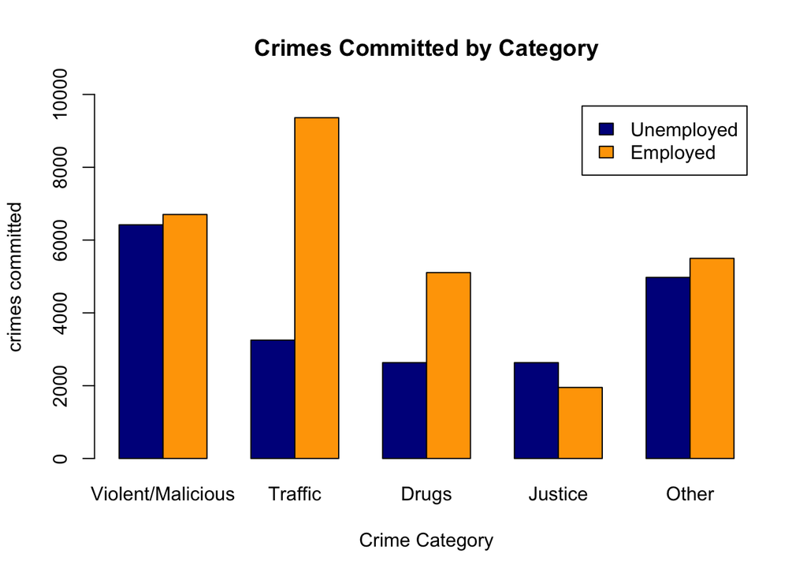

```r
graph1_data = rbind(c(6420,3252,2633,2633,4975), c(6703,9361,5107,1952,5498))

barplot(graph1_data, beside = TRUE, names.arg = c("Violent/Malicious","Traffic","Drugs","Justice","Other"), col = c("darkblue","orange"),main = "Crimes Committed by Category", ylim = c(0,10000), ylab = "crimes committed", xlab = "Crime Category", legend = c("Unemployed", "Employed") )
```

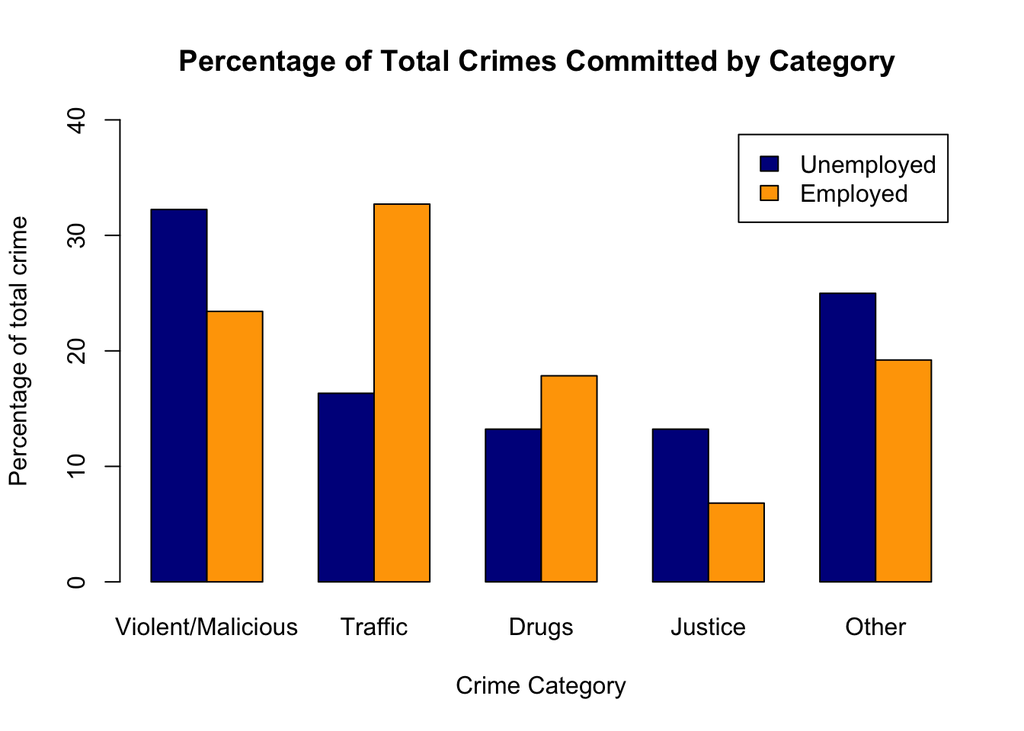

```r
graph2_data = rbind(c(32.24,16.33,13.223,13.223,24.984),c(23.42,32.707,17.844,6.82,19.21))

barplot(graph2_data,beside = TRUE, ylim = c(0,40), col = c("darkblue","orange"),main = "Percentage of Total Crimes Committed by Category ",xlab = "Crime Category", ylab = "Percentage of total crime", legend = c("Unemployed","Employed"), names.arg = c("Violent/Malicious","Traffic","Drugs","Justice","Other"))
```

One thing that surprised us about these results was that drug crimes were more common among employed people, however it does make logical sense given that drugs tend to be an expensive habit and employed people are generally more financially stable than unemployed people. This same logic also explains why traffic crimes are so much more revalent among the employed group.

Text Analysis for Unemployed people:

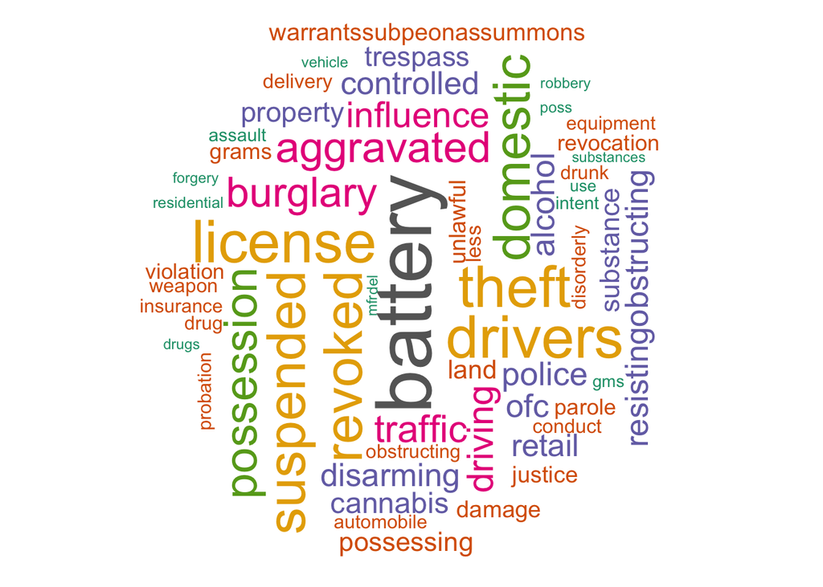

```r
wordcloud(words = d$word, freq = d$freq, min.freq = 200, random.order=FALSE, rot.per = .35,colors=brewer.pal(8,"Dark2"))
```

Text Analysis for Employed People:

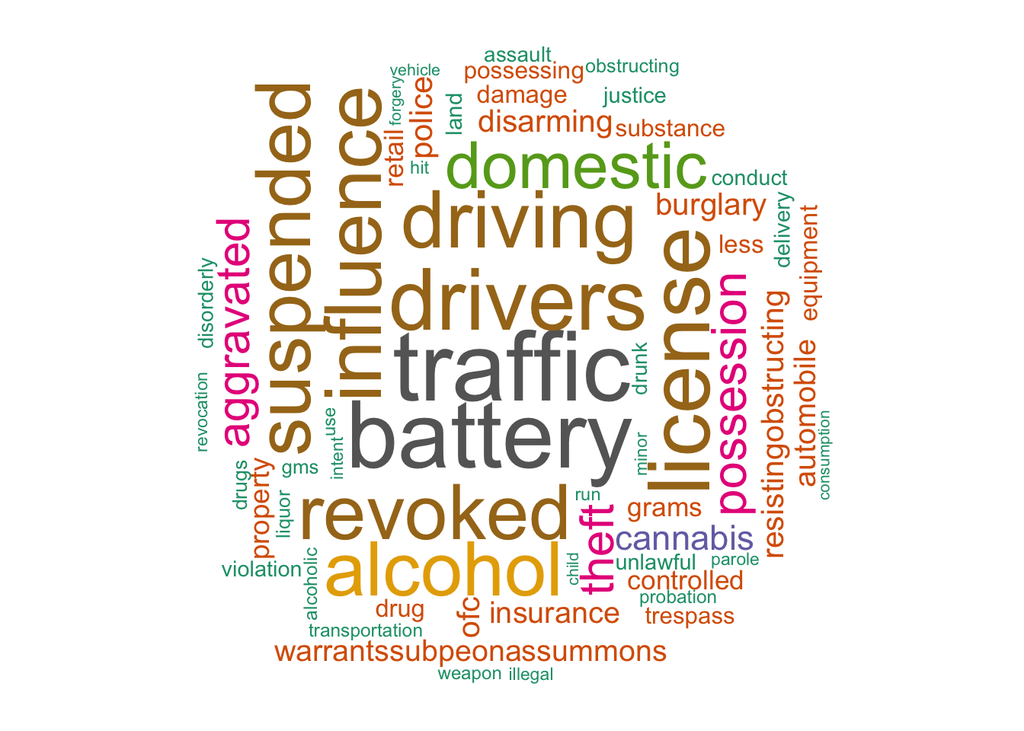

```r
wordcloud(words = d$word, freq = d$freq, min.freq = 200, random.order=FALSE, rot.per = .35,colors=brewer.pal(8,"Dark2"))
```

From these word clouds obtained from text mining we can see the visualized trend that unemployed people commit a high percentage of violent crime with the word “Battery” clearly at the forefront. We aslo observe the trend of traffic violations among employed people with words like “traffic”, “drivers”, “license”, “suspended”, etc. all very prevalent. It is also worth noting that there are many more prevalent words in the employed cloud than the umpemployed cloud which would suggest that the distribution of different crimes is more spread out among employed people.

#### Student Group - Crime Code Diversion in Age

For student group in this dataset, we consider age is a good variable to classify the types of crime, since students in different age group usually live in different environment and face different social problem. Therefore, it is important first to have a look on the distribution of crime code in student group.

However, since there are about 131 different crime codes are committed by students, it is too large for us to classify. We decide to merge crime code into five major crime code categories based on their attributes, which include traffic offenses, violent crime, social crime, property crime, and other crime.

```r
str(factor(ccso$crime))
```

```
##  Factor w/ 131 levels "AGGRAVATED ASSAULT",..: 46 2 21 88 50 46 112 88 84 112 ...
```

```r
str(factor(ccso2$crime))
```

```
##  Factor w/ 5 levels "Other Crime",..: 5 5 3 4 4 5 4 4 3 4 ...
```

The bar plot of frequency for crime types clearly shows that social crime and traffic offenses each is about 2 times than any other single category. Also, these two crime types together contribute to more than half of all crimes committed by students.

This interesting fact attracts our attention, and we then more focus on these two crime types.

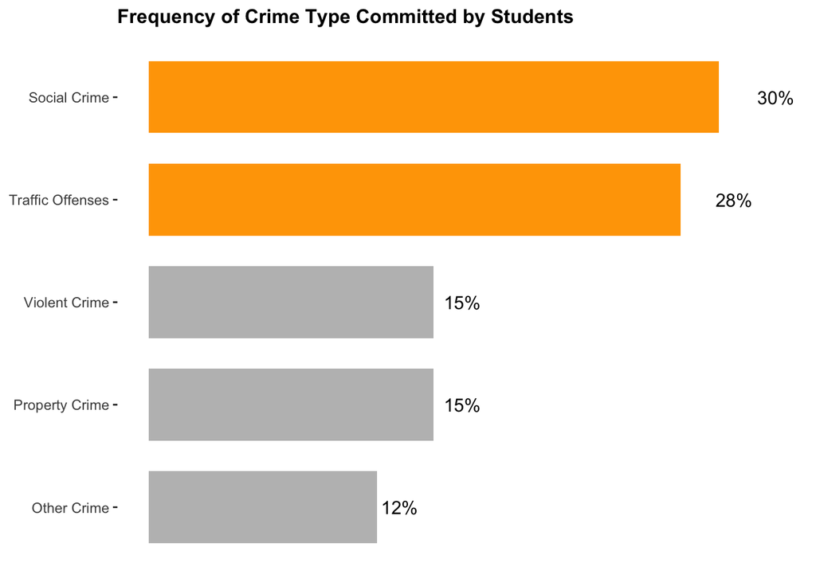

```r
frebp
```

The classification tree is build specifically for the two types of crime selected before, based on random sampling for 70% of the original data.

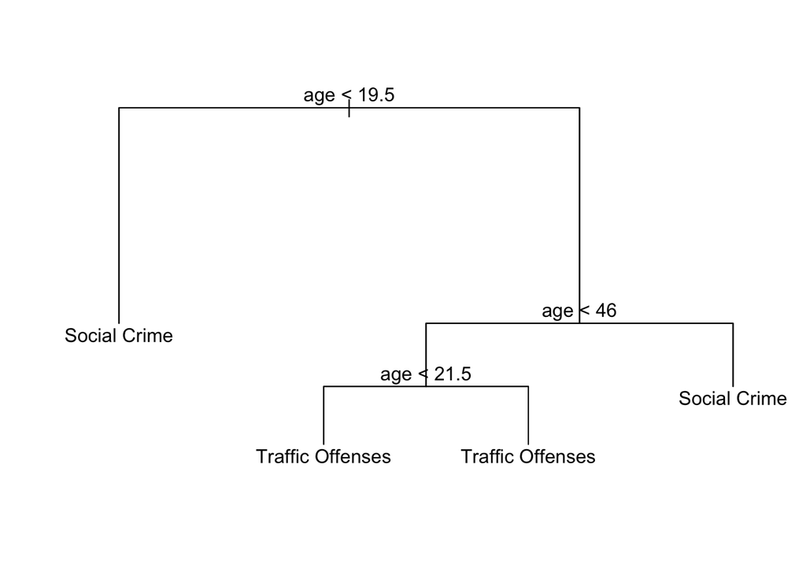

```r
plot(fittree)
text(fittree, pretty=0)
```

Moreover, we apply our model to predict the random sampling for remaining 30% of the original data, the testing data. We generate the confusion table of the result. It shows that we correctly classify about 77% of the social crime and about 61% of the traffic offenses. The correctness does not seem to be very high. We think some potential factors may be there are too many crime codes that are counted as social crime, since some outliers could highly affect our tree construction.

```r
#prediction on testing data
testingData_response <- testingData$crime
testpredz <- predict(fittree, testingData, type="class")
#Confusion table
round(prop.table(table(testpredz,testingData_response),1),2)
```

```
##                   testingData_response
## testpredz          Social Crime Traffic Offenses
##   Social Crime             0.77             0.23
##   Traffic Offenses         0.39             0.61
```

#### Military Group - Crime Code Diversion in Demographics

In this part, we will look into different crime types for people who were in military. To better examine the differences between different types of people, I first used k-means clustering to separate all these 2542 military observations into several clusters using demographic variables.

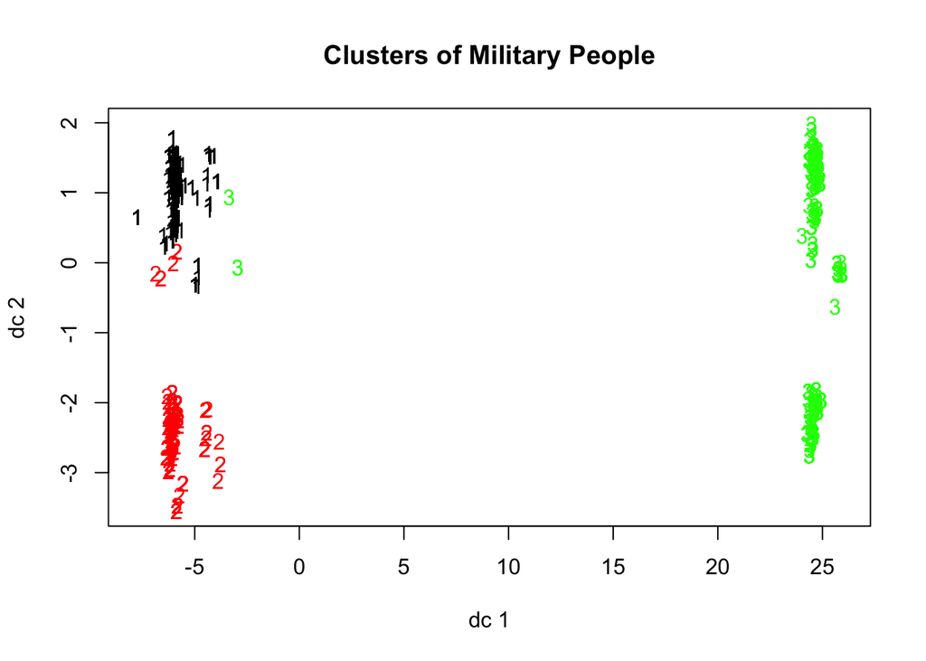

```r
# plot
library(cluster)
library(fpc)
plotcluster(q1M_dummies, demoClusterM$cluster)
title('Clusters of Military People')
```

From this plot, we can see that these observations are well separated into three clusters.

Then we can take a futher look into the details of these clusters to find out the differences between them.

```r
# RACE
print("RACE IN CLUSTER1")
```

```
## [1] "RACE IN CLUSTER1"
```

```r
table(cluster1$RACE)
```

```
##
## Asian/Pacific Islander               Hispanic                 Others
##                      6                     25                      4
##                  White
##                    902
```

```r
print("RACE IN CLUSTER2")
```

```
## [1] "RACE IN CLUSTER2"
```

```r
table(cluster2$RACE)
```

```
##
## Asian/Pacific Islander               Hispanic                 Others
##                     27                     17                      4
##                  White
##                    727
```

```r
print("RACE IN CLUSTER3")
```

```
## [1] "RACE IN CLUSTER3"
```

```r
table(cluster3$RACE)
```

```
##
## Asian/Pacific Islander                  Black               Hispanic
##                      1                    827                      2
```

```r
# MARITAL STATUS
print("MARITAL STATUS IN CLUSTER1")
```

```
## [1] "MARITAL STATUS IN CLUSTER1"
```

```r
table(cluster1$`MARITIAL STATUS`)
```

```
##
##          Divorced           Married         Seperated Significant Other
##               492               398                30                 9
##           Widowed
##                 8
```

```r
print("MARITAL STATUS IN CLUSTER2")
```

```
## [1] "MARITAL STATUS IN CLUSTER2"
```

```r
table(cluster2$`MARITIAL STATUS`)
```

```
##
##         Seperated Significant Other            Single
##                 3                 3               769
```

```r
print("MARITAL STATUS IN CLUSTER3")
```

```
## [1] "MARITAL STATUS IN CLUSTER3"
```

```r
table(cluster3$`MARITIAL STATUS`)
```

```
##
##          Divorced           Married         Seperated Significant Other
##               137               209                27                 1
##            Single           Widowed
##               413                43
```

```r
# Age
print("AGE IN CLUSTER1")
```

```
## [1] "AGE IN CLUSTER1"
```

```r
table(cluster1$`Age at Arrest`)
```

```
##
##   1   2   3   4   5   6   7
##   0 110 230 276 208  85  28
```

```r
print("AGE STATUS IN CLUSTER2")
```

```
## [1] "AGE STATUS IN CLUSTER2"
```

```r
table(cluster2$`Age at Arrest`)
```

```
##
##   1   2   3   4   5   6   7
##  27 399 194  76  51  24   4
```

```r
print("AGE STATUS IN CLUSTER3")
```

```
## [1] "AGE STATUS IN CLUSTER3"
```

```r
table(cluster3$`Age at Arrest`)
```

```
##
##   1   2   3   4   5   6   7
##   7 142 126 157 311  76  11
```

As we can see from the comparison above, these clusters are mainly distinguished from each other in three dimensions - race, marital status and age.

After the clustering, we can analyze the crime patterns for each cluster.

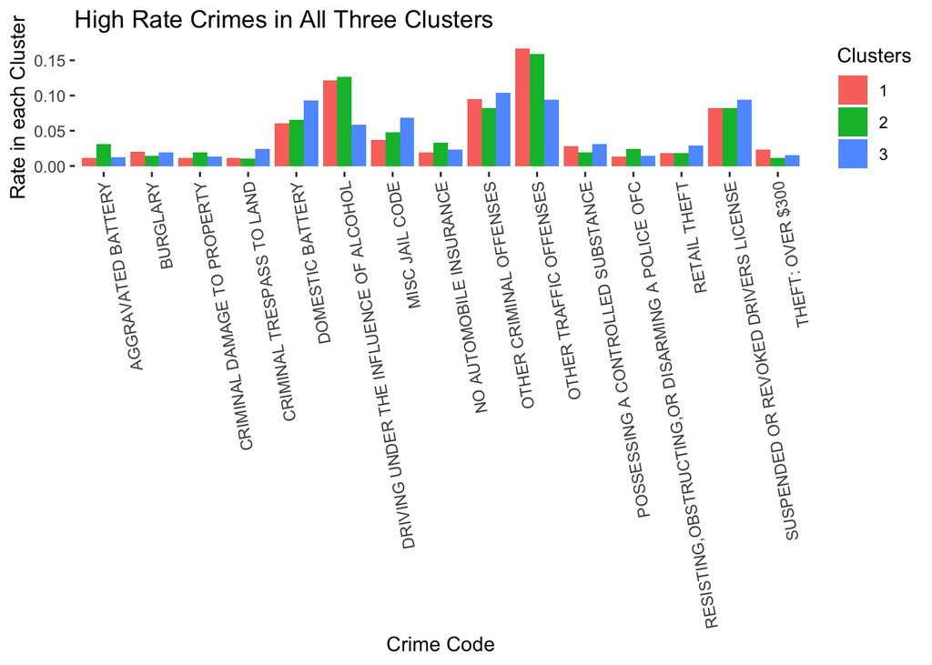

```r
# plot
ggplot(data = inter_top, mapping=aes(x = inter_top$`Crime Code`, y= inter_top$Ratio, fill = inter_top$Clusters)) +
  geom_bar(stat = 'identity', position = 'dodge') +
  xlab('Crime Code')+ ylab('Rate in each Cluster') +
  labs(title = "High Rate Crimes in All Three Clusters", fill="Clusters") +
  theme(axis.text.x=element_text(angle=100, hjust=1, vjust = 0.5), panel.background = element_blank())
```

So above is the plot showing all the crimes which appear as high-rate in all these three clusters. “High-rate” is defined as “higher than 0.01” which means one in one hundred people in that cluster has conducted this crime.

## Conclusion

Deeper analysis could be done to break each of our three groups into more refined categories to get a better idea of which types of people commit which crimes. For example we could classify students based on school atended, classify employment by sector in which jobs reside, and military status by military branch.